# Unsupervised Methods for Microarray Analysis; Clustering and PCA

Mark Dunning (Acknowledgements: Oscar Rueda, Matt Ritchie, Christina Curtis)

Last modified: 24 Jan 2017

# Clustering (and PCA)

## Clustering.. or Classification?

- **Unsupervised:** classes unknown, want to discover them from the data (cluster analysis)
- **Supervised:** classes are predefined, want to use a (training or learning) set of labelled objects to form a classifier for classification of future observations

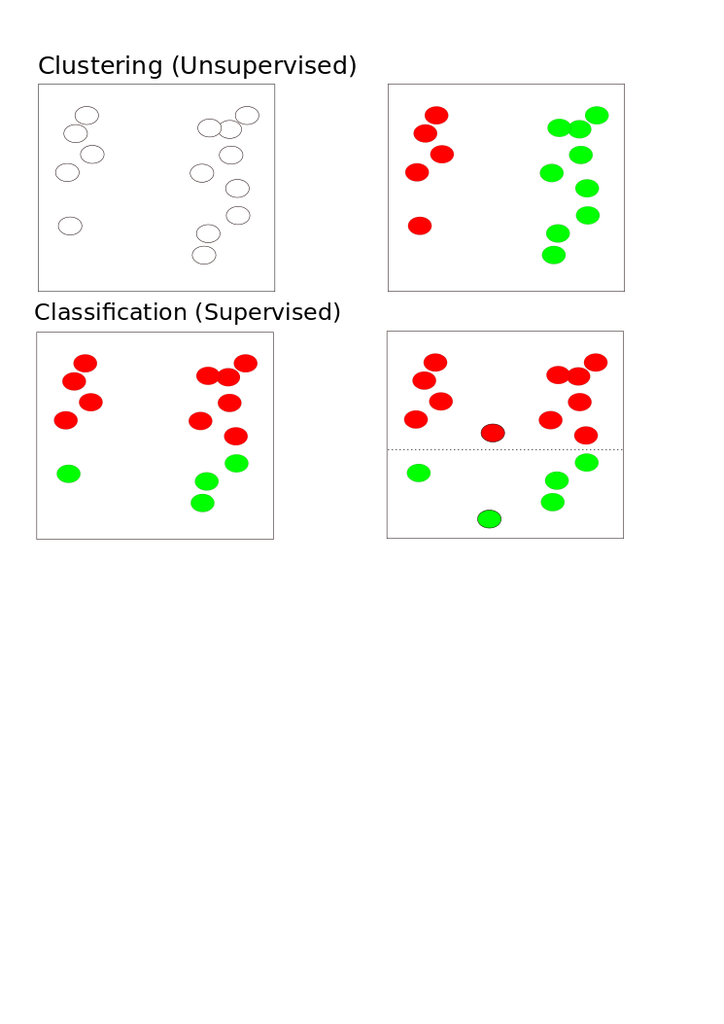

defs

## Why do clustering for genomic data?

- Clustering leads to readily interpretable figures and can be helpful for identifying patterns in time or space.
- We can cluster samples (columns)
  - e.g. identification of new / unknown tumor classes using gene expression profiles
- We can cluster genes (rows)
  - e.g. using large numbers of yeast experiments to identify groups of co-regulated genes
  - we can cluster genes to reduce redundancy (i.e. variable selection) in predictive models

### Subtype Discovery

- There are plenty of examples of using clustering to discover subtypes in the literature

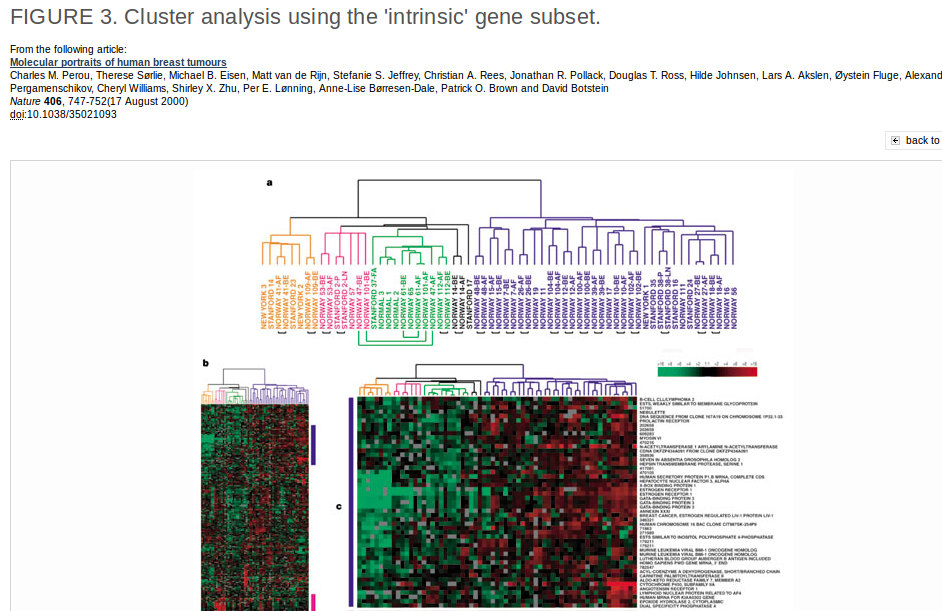

perou

### Clustering as QA

- Also used as a quality assessment tool
  - to check for outlier samples

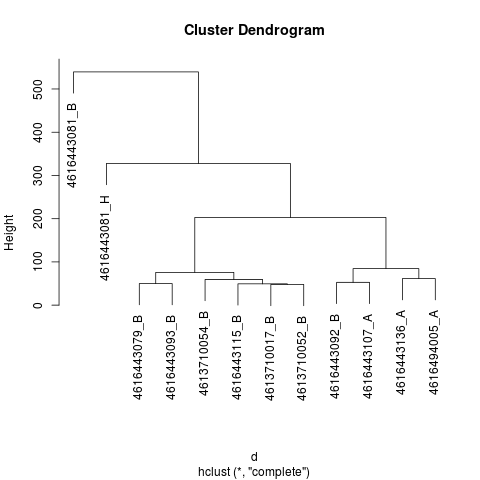

- Can check within / between experiment variability and potential confounding factors (batch effect etc)

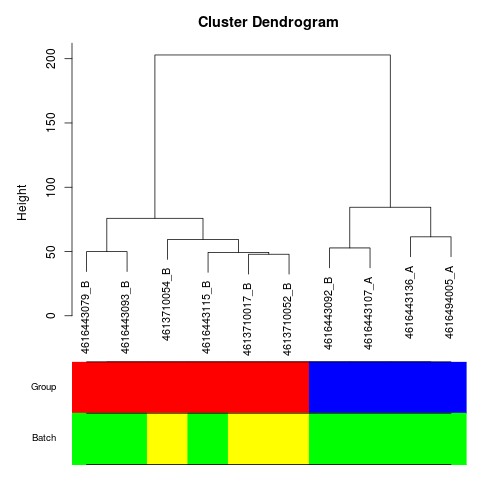

### Clustering Overview

- Steps in a Cluster Analysis
  1. Preprocess the data
  2. Choose a *dissimilarity* measure
  3. Choose a cluster algorithm
  4. Select the number of clusters
  5. Validate the procedure

When clustering genes, it is common to pre-process;

- normalise
- filter; remove genes with low variability across samples and many missing values
- (impute missing values)
- standardise; e.g. zero-mean and, unit variance:
  - $y_g^* = (y_g - \mu_g)/\sigma_g$

### How to compute similarity

Common *Similarity* / *Dissimilarity* measures include

- Correlation coefficient; *scale invariant*
  - Pearson’s correlation;
  - Spearman correlation of ranks
- Distance: scale dependant
  - Euclidean distance; $d(x,y) = \sqrt{\sum_i (x_i - y_i)^2}$
  - City block (Manhattan) distance; $d(x,y) = \sum | x_i - y_i |$
  - and others…..
- *Warning*: Don’t get too hung-up on the choice of measure
  - Clustering is primarily an exploratory tool
  - If your data has signal, it should show regardless of which measure you choose
  - Don’t just pick the one which “looks the best”

### How to compute similarity, in R

The `dist` function can be used to calculate a variety of similarity measures

- As usual, we can do `?dist`.
- The input is a matrix of numerical values
- Let’s test with some sample data

```r
myMatrix <- matrix(rnorm(1000),ncol=10)
colnames(myMatrix) <- LETTERS[1:10]
head(myMatrix)
```

```
              A          B          C           D          E           F          G          H          I          J
[1,]  0.6064441 -0.1476270 -0.5688675 -0.69223140  1.4850619  0.56543940  0.8373760  0.4354331 -1.2897906 -0.8532729
[2,] -0.1508486 -2.4030489  0.3707362 -0.02740857  0.5349538 -2.09018125  1.4436377  0.9029036  1.5616075  0.8045060
[3,]  0.3277493  0.4884857 -0.4094352 -0.37710171 -0.7629225  1.87997716 -0.2751674 -0.4535130  1.6566089 -0.1986223
[4,]  0.9927760 -0.8628563 -0.1433655 -0.08859960  1.0462481 -0.75932825 -0.3969960 -1.3035263  0.3596551  0.7425624
[5,] -1.2598369  2.1579949  0.6258192  0.24969655  1.5327056 -0.33147706  0.8371976  0.1767689  0.2351888  1.0043095
[6,]  0.6929038  0.9839626  0.9208382 -2.44084493 -0.3507557 -0.04487962 -0.2525927 -0.7399595  0.5569075  0.8653038
```

```r
d <- dist(myMatrix)
d
```

- The more common use of clustering is to cluster the columns (*samples*)
- To do this, we have to *transpose* the matrix; using the function `t`

```r
d
```

[output not shown]

- Changing the type of distance measure can be done by changing the `method` argument

```r
d.man <- dist(t(myMatrix),method="manhattan")
d.man
```

### How to calculate correlation in R

- This time we use the `cor` function (`?cor`)
- What do you notice about the output, compared to that of `dist`?

```r
cor(myMatrix)
```

- Clustering algorithms will expect input in distance matrix form
- We can convert using `as.dist`

```r
corMat <- as.dist(cor(myMatrix))
corMat
```

- Two samples with a *higher correlation* values means *more similar*
- …so the *distance* between is *less*

```r
corMat <- as.dist(1-abs(cor(myMatrix)))
corMat
```

### Correlation versus Distance

- A simple toy example of three genes
  - which genes seem to be closest?

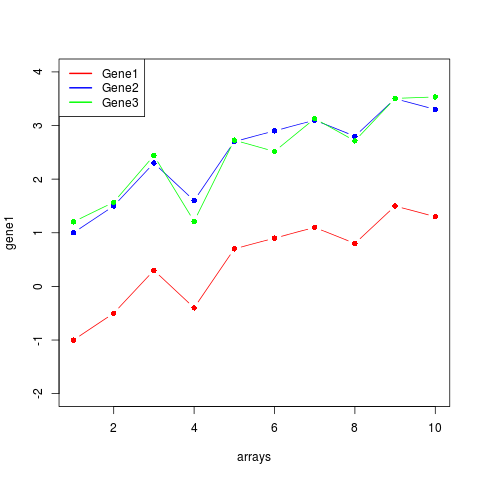

- Using Euclidean distance

```
          gene1     gene2
gene2 6.3245553
gene3 0.7184847 6.2188735
```

- Correlation matrix

```
          gene1     gene2     gene3
gene1 1.0000000 1.0000000 0.9665981
gene2 1.0000000 1.0000000 0.9665981
gene3 0.9665981 0.9665981 1.0000000
```

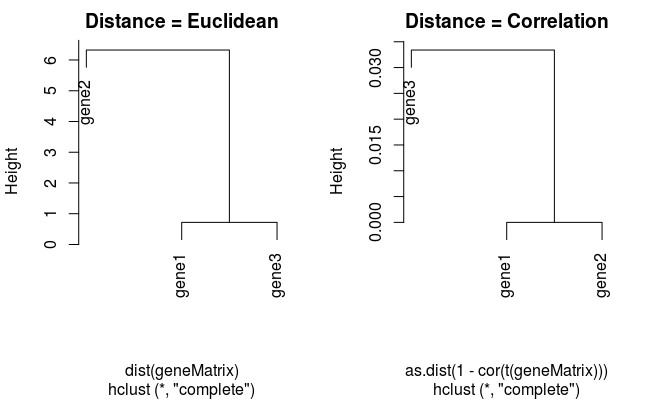

### Choice of algorithm

Clustering Algorithms

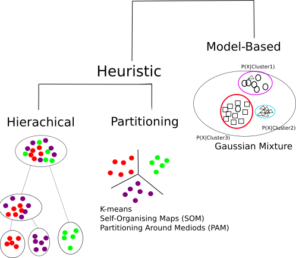

clust-methods

## Hierachical methods

- start with *n* samples (or $p$ gene) clusters
- At each step, *merge* the two closest clusters using a measure of *between-cluster* dissimilarity which reflects the shape of the clusters
- The distance between the clusters is defined by the method used (e.g. in *complete linkage*, the distance is defined as the distance between the furthest pair of points in the two clusters)

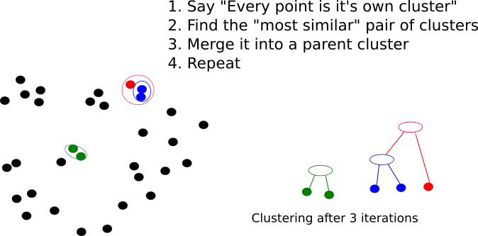

the-algorithm

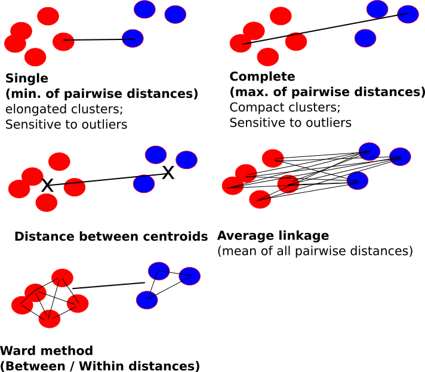

between-clusters

- Dendrograms are good visual guides, but *arbitrary*
- Nodes can be reordered
  - Closer on dendrogram $\ne$ more similar

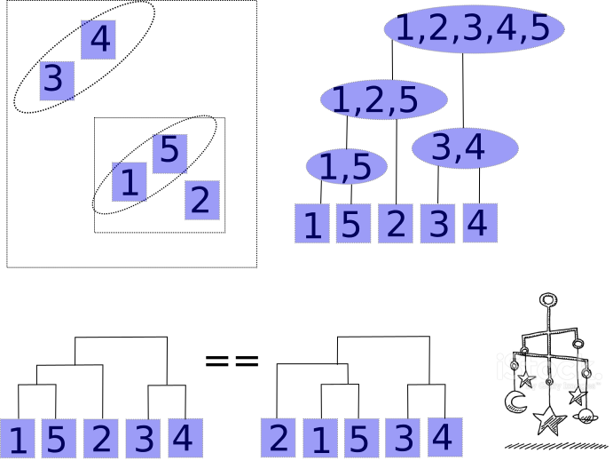

hierarchical

### Performing hierachical clustering, in R

- The function to use here is `hclust` (`?hclust`)
- It takes a distance matrix that you computed previously

```r
clust <- hclust(d)
clust
```

- The standard plotting function has been extended to visualise the result of the clustering

```r
plot(clust)
```

- We can change the name of the method

```r
clust.ward <- hclust(d,method = "ward.D")
par(mfrow=c(1,2))
plot(clust)
plot(clust.ward)
```

- Two useful functions are `cutree` and `rect.hclust`
- Can be used to “cut” the dendrogram at a particular height

```r
par(mfrow=c(1,1))
plot(clust)
cutree(clust, h=16)
rect.hclust(clust, h=16)
```

- Alternatively, we can see the number of clusters; *k*
- Try experimenting with different values of k….

```r
plot(clust)
cutree(clust, k=2)
rect.hclust(clust, k=2)
```

## Summary of clustering

- Useful as *exploratory / visualisation* tools
- Choice of metric, methods and parameters usually guided by prior knowledge about the question
  - The result is guided by what you are looking for
- Validate using different algorithms
- Use prior Biological knowledge, or your sample meta data to see if the clusters make sense
- Be aware
  - Clustering will always produce something. It cannot NOT work
- Clustering is a generic technique that can be applied to many forms of data
  - We will use it on Microarrays, but it can be used on RNA-seq, ChIP, or other NGS data
- Quality assessment of samples
  - checking for batch effects and outliers
  - check effectiveness of normalisation / transformation

# Principal Components Analysis (PCA)

## Why Use PCA

- In genomic data, we have a large number of variables which are often highly correlated
- PCA is one of many *dimension-reduction* techniques that can remove redundancy and give a smaller more mangeable set of variables. In summary it can help us to:-
- Reduce *dimensionality* of the data
- Decrease the *redundancy* of the data
- Filter the *noise* in the data
- *Compress* the data

## PCA Example: Whisky

The data: 86 malt whiskies scored for 12 different taste categories

(https://www.mathstat.strath.ac.uk/outreach/nessie/nessie_whisky.html)

- Q. Can we find which whiskies have a similar taste profile?
- Q. What are the factors that determine the taste profile?

|  | Body | Sweetness | Smoky | Medicinal | Tobacco | Honey | Spicy | Winey | Nutty | Malty | Fruity | Floral |
| --- | --- | --- | --- | --- | --- | --- | --- | --- | --- | --- | --- | --- |
| Aberfeldy | 2 | 2 | 2 | 0 | 0 | 2 | 1 | 2 | 2 | 2 | 2 | 2 |
| Aberlour | 3 | 3 | 1 | 0 | 0 | 4 | 3 | 2 | 2 | 3 | 3 | 2 |
| AnCnoc | 1 | 3 | 2 | 0 | 0 | 2 | 0 | 0 | 2 | 2 | 3 | 2 |

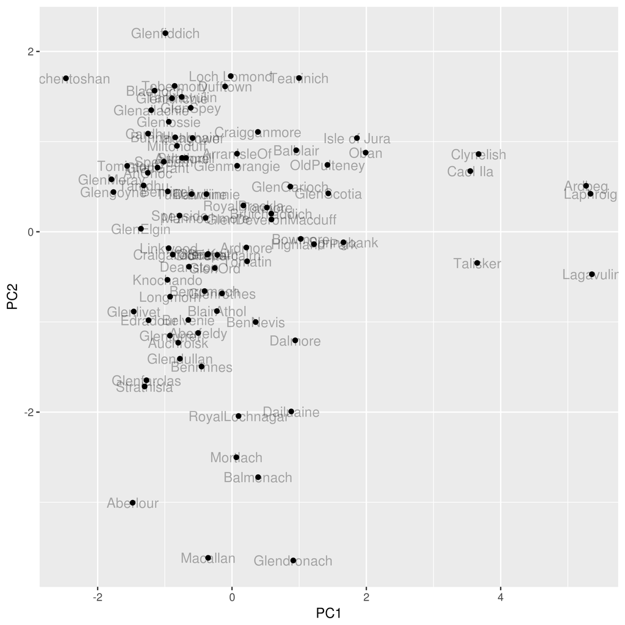

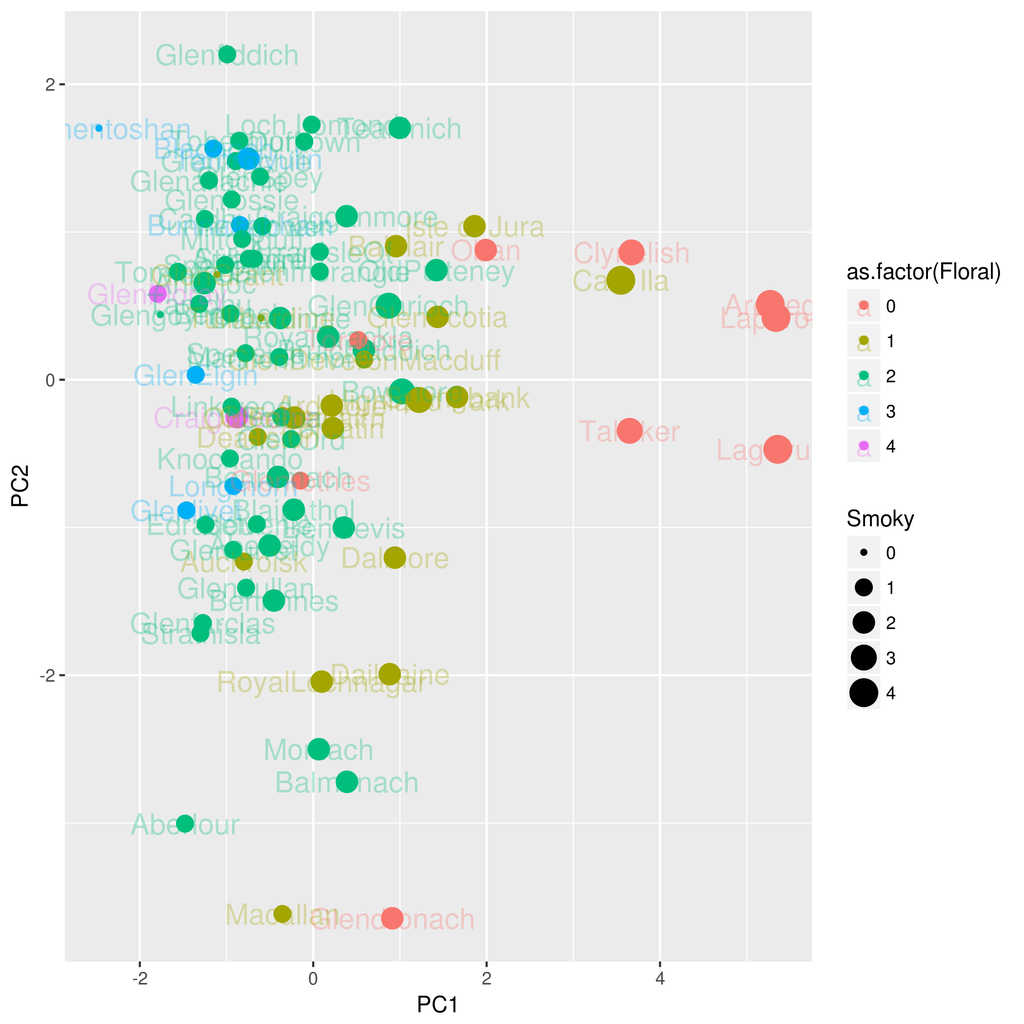

## More-relevant example

- MAQC microarrays with mixtures of Brain and Reference RNA (UHRR) at different concentrations
- Run in different labs
  - what do you notice?

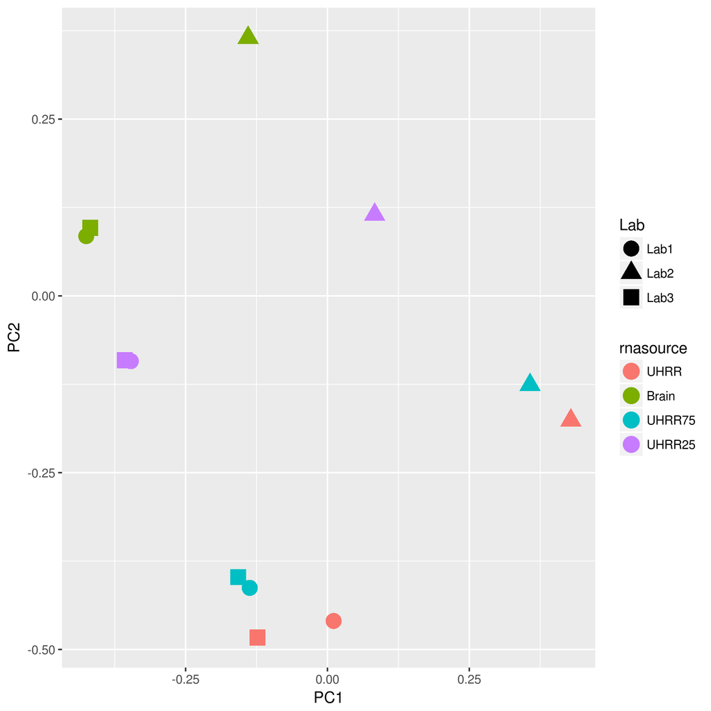

## More-relevant example

So, PCA can be used as a quality assessment tool and can inform us of any factors we need to account for in the analysis

- In this case we could correct for the batch effect, or add a batch factor to the linear model for analysis

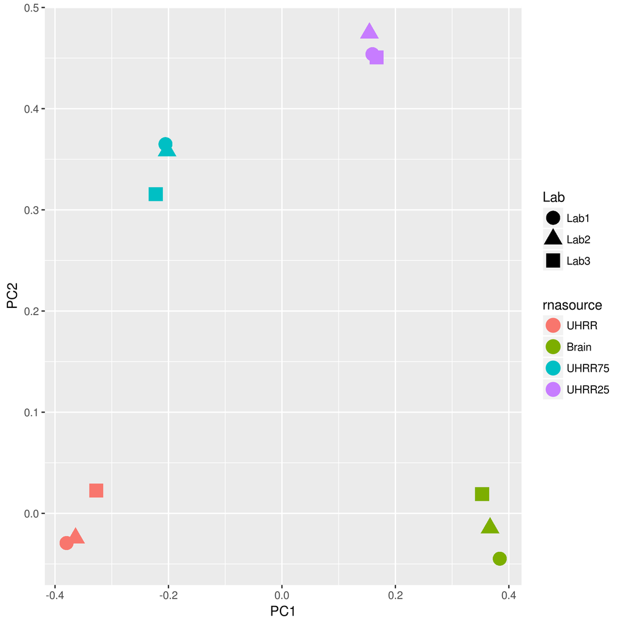

## What is going-on here?

A two-dimensional case

- Find direction of most variation (PC1)
- Direction that explains next amount of variation is orthogonal (at 90 degrees) (PC2)
- Each point on original x and y is a linear combination of PC1 and PC2
- Higher dimensional data can have many more components PC3, PC4….
  - although they will become increasingly less-influential

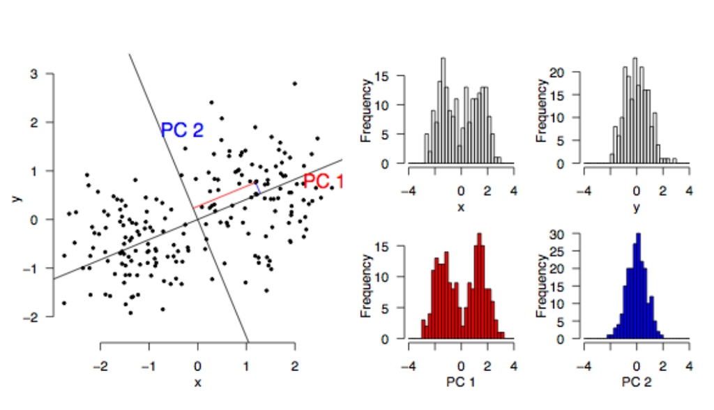

pca-explained

## Worked example

Getting the data…

```r
whisky <- read.csv("https://www.mathstat.strath.ac.uk/outreach/nessie/datasets/whiskies.txt")
scores <- whisky[,c(3:14)]
rownames(scores) <- whisky$Distillery
head(scores,n=3)
```

|  | Body | Sweetness | Smoky | Medicinal | Tobacco | Honey | Spicy | Winey | Nutty | Malty | Fruity | Floral |
| --- | --- | --- | --- | --- | --- | --- | --- | --- | --- | --- | --- | --- |
| Aberfeldy | 2 | 2 | 2 | 0 | 0 | 2 | 1 | 2 | 2 | 2 | 2 | 2 |
| Aberlour | 3 | 3 | 1 | 0 | 0 | 4 | 3 | 2 | 2 | 3 | 3 | 2 |
| AnCnoc | 1 | 3 | 2 | 0 | 0 | 2 | 0 | 0 | 2 | 2 | 3 | 2 |

## Running the PCA

The `prcomp` function does the hard-work for us

- It is computing *eigenvectors* and *eigenvalues* from our input matrix
  - or rather the covariance matrix
- We have 12 components (as we had 12 variables)
- The components are ordered according to the amount of variance they *explain*

```r
pca <- prcomp(scores)
summary(pca)
```

```
Importance of components:
                          PC1    PC2    PC3    PC4     PC5     PC6     PC7     PC8     PC9    PC10    PC11    PC12
Standard deviation     1.5358 1.2270 0.8654 0.8039 0.75261 0.68513 0.63256 0.59943 0.52347 0.50049 0.42422 0.27266
Proportion of Variance 0.3011 0.1922 0.0956 0.0825 0.07231 0.05992 0.05108 0.04587 0.03498 0.03198 0.02297 0.00949
Cumulative Proportion  0.3011 0.4933 0.5889 0.6714 0.74370 0.80363 0.85471 0.90058 0.93556 0.96754 0.99051 1.00000
```

## Dissecting the PCA results

- Each column in a principal component
  - in decreasing order of importance
- The values are the measure of importance for each component
  - e.g. Smoky seems to be important for PC1
  - Smoky and Floral are opposite ends of the spectrum for PC1

```r
pca$rotation[,1:5]
```

```
                  PC1         PC2           PC3         PC4          PC5
Body       0.36119005 -0.49130643  0.0301178096 -0.07460952  0.227019231
Sweetness -0.20298238 -0.04659634 -0.2638792230 -0.37063897  0.009220720
Smoky      0.47794419 -0.06874216  0.2188100647  0.08852143 -0.201614612
Medicinal  0.57527678  0.16079484  0.0431598432  0.08237288 -0.033120119
Tobacco    0.09173306  0.02004776 -0.0006685359 -0.03337611 -0.008967789
Honey     -0.22090804 -0.41799491  0.1102471134  0.03315990 -0.596888644
Spicy      0.05811101 -0.17548310  0.6992443906 -0.17163088 -0.133792990
Winey     -0.03745608 -0.63964979 -0.2331295871 -0.22573776  0.110928262
Nutty     -0.04766410 -0.26036122 -0.1785529039  0.85059012  0.025288924
Malty     -0.12781608 -0.10296202  0.1084169899  0.07177790 -0.105401421
Fruity    -0.20235755 -0.12374977  0.4034627791  0.09457148  0.702770800
Floral    -0.38394443  0.13074914  0.3433008365  0.14903423 -0.120141367
```

## How many components?

We look at the variance explained by each component and judge where it “drops-off”

- Sometimes called a “scree-plot”

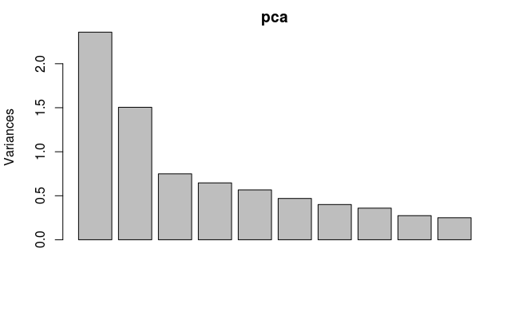

```r
plot(pca)
```

## How many components?

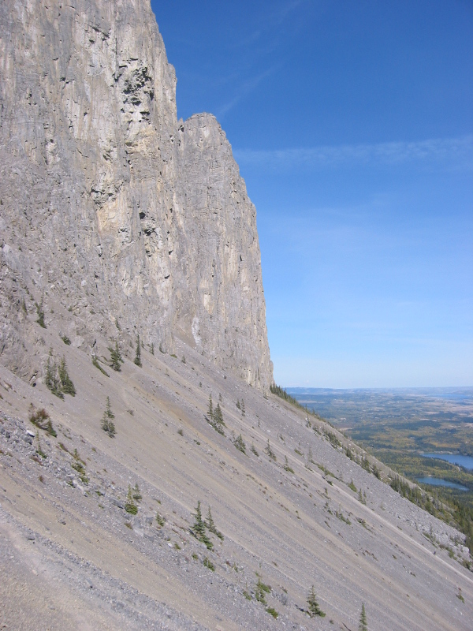

scree

## Dissecting the PCA results

The new co-ordinate system is given by `pca$x`

- One row for each of our whiskies, one column for each component
- The original coordinates are a linear combination of the new ones
  - an exercise for the reader?

```r
pca$x[1:3,1:5]
```

```
                 PC1        PC2        PC3        PC4        PC5
Aberfeldy -0.5033841 -1.1220223 -0.1612002  0.5058255 -0.2841501
Aberlour  -1.4788883 -3.0048507  1.5170911 -0.1385370 -0.7102894
AnCnoc    -1.2531129  0.6537207 -0.2847196  0.9274739  0.1127587
```

## Dissecting the PCA results

`ggplot2` is especially convenient for visualising the results

- An overlay of the known variables will highlight the patterns
- As with clustering, PCA is to be used as an exploratory tool

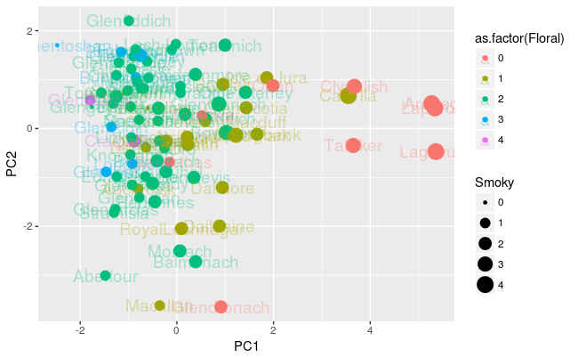

```r
df <- data.frame(whisky,pca$x)
ggplot(df, aes(x=PC1,y=PC2,label=Distillery,cex=Smoky,col=as.factor(Floral))) + geom_point() + geom_text(cex=5,alpha=0.3)
```